# Project_v3

Author

Patrick Torralba

# Research Question: Can we predict my stress levels in the near-future?

To answer this question, we must account for variables that I believe influence my stress levels. These variables are mainly split into academic and non-academic stressors as noted in the Section 3.1.1 portion.

# Set-up

## Library

```r
library(tidyverse)
library(readxl) ## load data
library(lubridate) ## clean date columns
library(gtsummary) ## make nice tables
library(gt) ## make table 1
library(tidymodels) ## make linear reg model
library(kableExtra) ## needed for tables
```

## Load Data

My stress level data comes from my Garmin watch which I wear every day. I was able to download a .xlsx file containing my weekly average stress levels directly from Garmin.

Please note, I do not wear the watch at night when I sleep, and thus, this data only reflects my stress levels when I am awake. Unfortunately, Garmin does not provide units to said stress levels and there are more limitations as noted in the Section 5.2.1.

```r
avg_stress <- read_excel("stress_data_avg.xlsx")
```

# Data Wrangling

## Data Cleaning

I subset the dataset into a new dataset, “avg_stress_clean”, to ensure that the original dataset remains static in case something goes wrong and I need to compare values.

I first cleaned the data by removing NA values from the stress column “Avg”. I then cleaned the date column by extracting only the start of the week and pasting the year (e.g May 21, 2025).

### Stress variables

Additional columns were created for analysis purposes: roommate_status, stressful_event, exam_season, graduate_school, and academic_break. Respectively, the first variable refers to my living arrangements including pre-roommate [living with family], roommate, and post-roommate [living by myself]. The second variable includes non-academic stressful events that were an extreme source of frustration for me such as a flat tire, a missed paycheck, etc. Lastly, the third variable refers to academic stressors such as mid-terms and final exams.

```r
avg_stress_clean <- avg_stress %>%
  filter(!is.na(Avg)) %>% ## remove NA values
  mutate(
    start_date_text = str_extract(Date, "^[^-]+"),
    year = if_else(str_detect(Date, "2025"), "2025", "2026"),
    start_date_text_v2 = str_extract(start_date_text, "^[^,]+"),   ## ensure that all date rows do not have a year
    date = paste(start_date_text_v2, year), ## TLDR: I reduced the Date column to the first listed month-day and separated the year. I needed to do this to create a clean_date column for R to recognize
    clean_date = mdy(date),
    roommate_status = case_when(clean_date <= ymd("2025-09-15") ~ "Pre-roommate",
                                clean_date >= ymd("2025-09-16") & clean_date <= ymd("2026-03-20") ~ "Roommate",
                                clean_date >= ymd("2025-03-21") ~ "Post-roommate"
    ),
    roommate_status = factor(roommate_status, levels = c("Pre-roommate","Roommate","Post-roommate")),
    stressful_event = case_when(
      clean_date >= ymd("2025-07-08") & clean_date <= ymd("2025-07-24") ~ "Yes",
      clean_date >= ymd("2025-09-05") & clean_date <= ymd("2025-09-16") ~ "Yes",
      .default = "No"
    ),
    exam_season = case_when(
      clean_date >= ymd("2025-12-12") & clean_date <= ymd("2025-12-18") ~ "Yes", # F25 finals
      clean_date >= ymd("2026-05-07") & clean_date <= ymd("2026-05-12") ~ "Yes", # S26 finals
      clean_date >= ymd("2026-03-23") & clean_date <= ymd("2026-03-29") ~ "Yes", # S26 midterms
      clean_date >= ymd("2025-10-20") & clean_date <= ymd("2025-10-24") ~ "Yes",  # F25 midterms
      .default = "No"
    ),
    graduate_school = case_when(clean_date >= ymd("2025-09-02") ~ "Yes", .default = "No"), # grad school start,
    academic_break = case_when(
      clean_date >= ymd("2025-11-27") & clean_date <= ymd("2025-11-30") ~ "Yes", # Thanksgiving break
      clean_date >= ymd("2025-12-18") & clean_date <= ymd("2026-01-20") ~ "Yes", # Winter break
      clean_date >= ymd("2026-03-12") & clean_date <= ymd("2026-03-15") ~ "Yes", # Spring break
      .default = "No"
    )
  ) %>%
  select(clean_date, year, roommate_status, stressful_event, graduate_school, exam_season, academic_break, Avg) ## only keep what I need. Easier to read.

avg_stress_clean
```

```
# A tibble: 55 × 8
   clean_date year  roommate_status stressful_event graduate_school exam_season
   <date>     <chr> <fct>           <chr>           <chr>           <chr>
 1 2026-04-21 2026  Post-roommate   No              Yes             No
 2 2026-04-13 2026  Post-roommate   No              Yes             No
 3 2026-04-06 2026  Post-roommate   No              Yes             No
 4 2026-03-29 2026  Post-roommate   No              Yes             Yes
 5 2026-03-22 2026  Post-roommate   No              Yes             No
 6 2026-03-15 2026  Roommate        No              Yes             No
 7 2026-03-08 2026  Roommate        No              Yes             No
 8 2026-03-01 2026  Roommate        No              Yes             No
 9 2026-02-22 2026  Roommate        No              Yes             No
10 2026-02-15 2026  Roommate        No              Yes             No
# ℹ 45 more rows
# ℹ 2 more variables: academic_break <chr>, Avg <dbl>
```

## Descriptive Statistics

I wanted to see what my average minimum and maximum stress levels were by roommate status.

```r
table_1 <- avg_stress_clean %>%
  group_by(roommate_status) %>%
  summarize(max_avg_stress = max(Avg, na.rm = TRUE),
            min_avg_stress = min(Avg, na.rm = TRUE)) %>%
  gt() %>%
  tab_header(
    title = "Patrick's Stress Levels by Roommate Status"
  ) %>%
  cols_label(
    roommate_status = "Roommate Status",
    max_avg_stress = "Maximum Stress",
    min_avg_stress = "Minimum Stress"
  )


table_1
```

Table 1: Patrick Stress Statistics: 2025-2026

Patrick's Stress Levels by Roommate Status

| Roommate Status | Maximum Stress | Minimum Stress |
| --- | --- | --- |
| Pre-roommate | 55 | 33 |
| Roommate | 72 | 47 |
| Post-roommate | 59 | 46 |

# Data Visualization

## Exploratory Plot

This plot represents my stress level trends from mid-2025 to present day according to roommate status.

It is interesting to note that my stress levels appear to dip once I move away from my roommate.

Figure 1: Patrick’s Stress Levels in Chronological Order

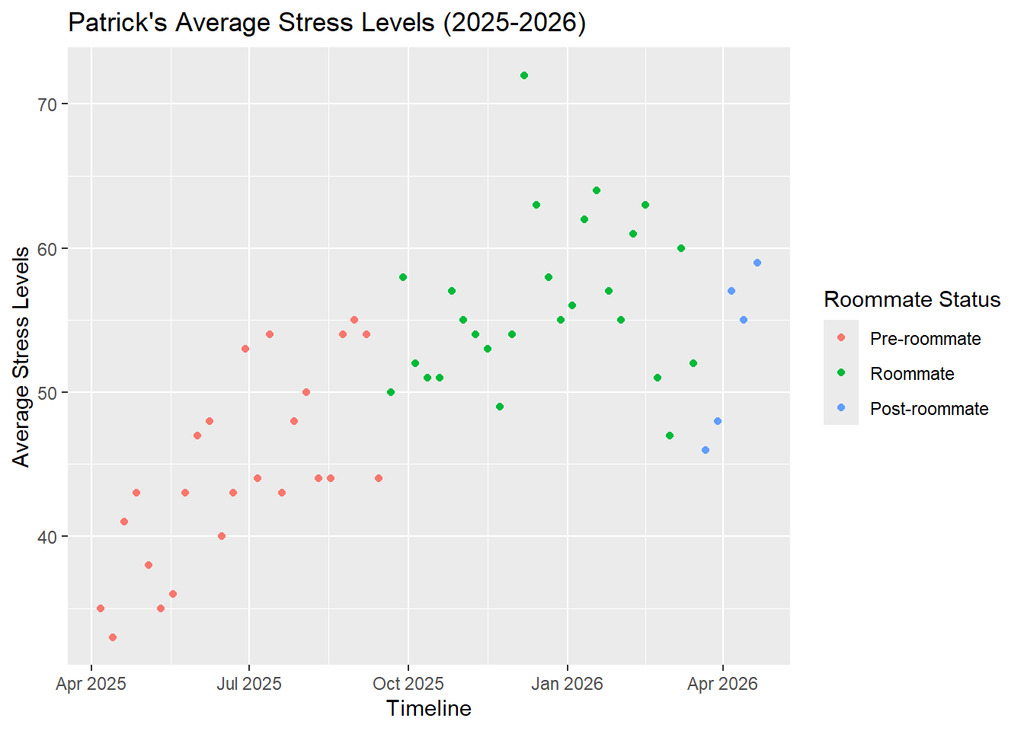

```r
ggplot(avg_stress_clean, aes(x = clean_date, y = Avg, color = roommate_status)) +
  geom_point() +
  labs(x = "Timeline",
       y = "Average Stress Levels",
       color = "Roommate Status",
       title = "Patrick's Average Stress Levels (2025-2026)")
```

## Communicative Plot

This plot represents the cumulative average stress levels by roommate status and exam season. It appears that my stress levels are similar when comparing stress levels during exam seasons.

Figure 2: Unadjusted Stress Levels

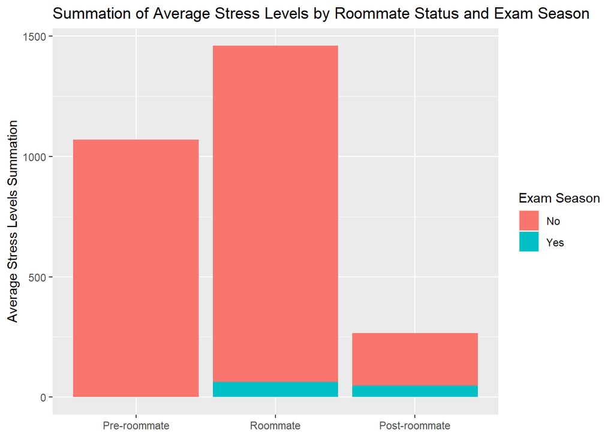

```r
ggplot(avg_stress_clean, aes(x = roommate_status, y = Avg, fill = exam_season)) +
  geom_col() +
  labs(x = NULL,
       y = "Average Stress Levels Summation",
       fill = "Exam Season",
       title = "Summation of Average Stress Levels by Roommate Status and Exam Season")
```

# Modeling

## Adjusted Linear Regression Model

I create a continuous prediction model because I want to predict my stress levels (e.g a numeric value) based on the presence of certain variables (e.g exam season vs no exam season).

### Data Split

In this step, we define our data split with a random number generator. Specifically, 80% of the dataset is allocated for training and 20% is for testing.

```r
set.seed(123)

data_split <- initial_split(avg_stress_clean, prop = 0.80)

train_data <- training(data_split)

test_data <- testing(data_split)
```

### Define Continuous Prediction Model

I define the model as a linear regression model.

```r
lm_spec <- linear_reg() %>%
  set_engine("lm") %>%
  set_mode("regression")
```

### Define Recipe

In laymans terms, the recipe is defined as the following equation:

$$\begin{split}
\text{Average Stress Levels} = \beta_0 \\ +
(\beta_1 \times \text{Roommate Status}) \\ +
(\beta_2 \times \text{Stressful Event}) \\ +
(\beta_3 \times \text{Exam Season}) \\ +
(\beta_4 \times \text{Graduate School}) \\ +
(\beta_5 \times \text{Academic Break})
\end{split}$$
In which my average stress levels are equivalent to my roommate status, stressful event, exam season, graduate school and academic breaks.

I also introduce step variables to recipe such as converting nominal predictors into binary variables, standardize numeric data to have a mean of zero and standard deviation of one, adjusting for the interaction effect between the roommate status coinciding with graduate school timing, and remove variables that have zero variance (e.g only 1 value).

```r
lm_recipe <- recipe(
  Avg ~ roommate_status + stressful_event + graduate_school + exam_season + academic_break,
  data = train_data
) %>%
  step_dummy(all_nominal_predictors()) %>% ## make categorical variables into binary
  step_normalize(all_predictors()) %>%
  step_interact(terms = ~ starts_with("roommate_status"):starts_with("graduate_school")) %>%  # create interaction effect between roommate status and graduate school
  step_zv(all_predictors()) %>%  ## remove zero variance predictors
  step_lincomb(all_predictors()) %>%
  step_corr(all_predictors(), threshold = 0.9) ## remove perfectly correlated variables
```

### Combine into Workflow

The workflow step is a container object that bundles the model and recipe together.

```r
lm_workflow <- workflow() %>%
  add_model(lm_spec) %>%
  add_recipe(lm_recipe)
```

### Fit Model

In this step, we let the model learn by feeding it the training data (e.g that 80% we allocated). The tidy step is to create a clean tibble.

```r
lm_fit <- fit(lm_workflow, data = train_data)

extract_fit_parsnip(lm_fit) %>% tidy()
```

```
# A tibble: 7 × 5
  term                                    estimate std.error statistic   p.value
  <chr>                                      <dbl>     <dbl>     <dbl>     <dbl>
1 (Intercept)                               51.1       0.973    52.6    4.30e-37
2 roommate_status_Roommate                   5.87      1.15      5.11   9.34e- 6
3 roommate_status_Post.roommate              2.05      1.12      1.84   7.36e- 2
4 stressful_event_Yes                        0.976     1.02      0.954  3.46e- 1
5 exam_season_Yes                            0.484     1.04      0.463  6.46e- 1
6 academic_break_Yes                         0.615     1.05      0.585  5.62e- 1
7 roommate_status_Roommate_x_graduate_sc…   NA        NA        NA     NA
```

### Evaluate Performance

Finally, we evaluate our model’s performance by using test data and by checking the metrics. We want to ensure that our model didn’t just simply memorize the training data, but can actually predict stress levels using new values. Essentially we are comparing our predicted stress levels to the actual data.

```r
# Make predictions
results <- predict(lm_fit, new_data = test_data) %>%
  bind_cols(test_data)

# Check metrics
metrics <- metrics(results, truth = Avg, estimate = .pred)


metrics %>%
  kable(
    format = "html",
    caption = "Linear Regression Model Performance",
    digits = 3) %>%
  kable_styling(
    bootstrap_options = c("striped", "hover", "condensed", "responsive"),
    full_width = FALSE,
    position = "left"
  )
```

Linear Regression Model Performance

| .metric | .estimator | .estimate |
| --- | --- | --- |
| rmse | standard | 4.723 |
| rsq | standard | 0.636 |
| mae | standard | 3.884 |

## Interpretation and Reflection

According to our evaluative performance results, we have an R-squared value of 0.636, mean absolute error (mae) of 3.884, and a root mean squared error (rmse) of 4.723 In other words, my model can explain ~63.6% of my average stress levels and thus, my model is a moderate-to-strong fit. The mae means that my model is off by about 3.9 stress level units. And, the rmse suggests that there’s a few instances where my model performed poorly (e.g had really large residuals).

### Limitations

As noted earlier, there are limitations to this analysis. The biggest confounder and limitation of the Garmin watch itself is that it cannot differentiate between positive excitement and negative anxiety, both of which can increase stress levels. Therefore, it is entirely possible that those instances I was stressed may just be me feeling extremely excited (e.g spending time with family).

Another significant limitation of this analysis is that I only have roughly 6 weeks of post-roommate stress level data, whereas, I have several months of pre-roommate and roommate data. Therefore, more post-roommate stress levels data need to be collected to create a more accurate model.

I also recommend conducting tests to determine if highly correlated variables could be artificially inflating the R-squared value.

### Reflection

Throughout this project, I learned how to make and train a linear regression! I thought this project was really interesting because I could define stressors, account for said stressors (e.g step_corr to remove highly correlated variables), and interpret these findings. I thought this was a cool way to actually apply what I’m learning in statistics to a tangible opportunity.